# Day 16

## Review

A **standard normal distribution** is a normal distribution with:

- $\mu=0$
- $\sigma = 1$

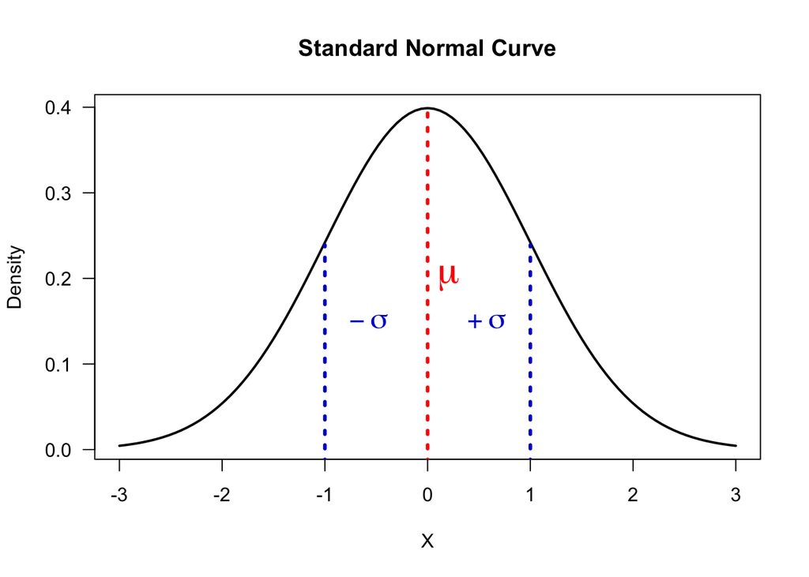

We use the letter $Z$ to represent a standard normal random variable (referring to $z$-score)

The probability that a **standard normal random variable** $Z$ is between $a$ and $b$ ($P(a<Z<b)$) is equal to the **area under the standard normal curve** over the interval $[a,b]$

To make **inference** about the standard Normal distribution, for this class we use the $z$-table

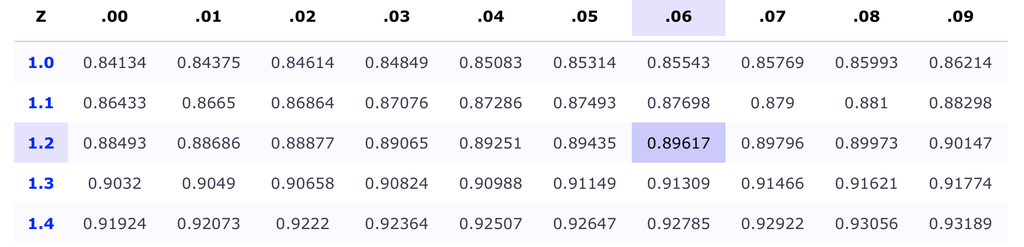

- Reading it isn’t difficult
- You can put a reminder on your cheat sheet if you so choose:

$$L+T=1.26$$

**The difficulty is getting to the point where we read it**

> Conceptually you need to grasp a couple things:

[figure not shown]

[figure not shown]

[figure not shown]

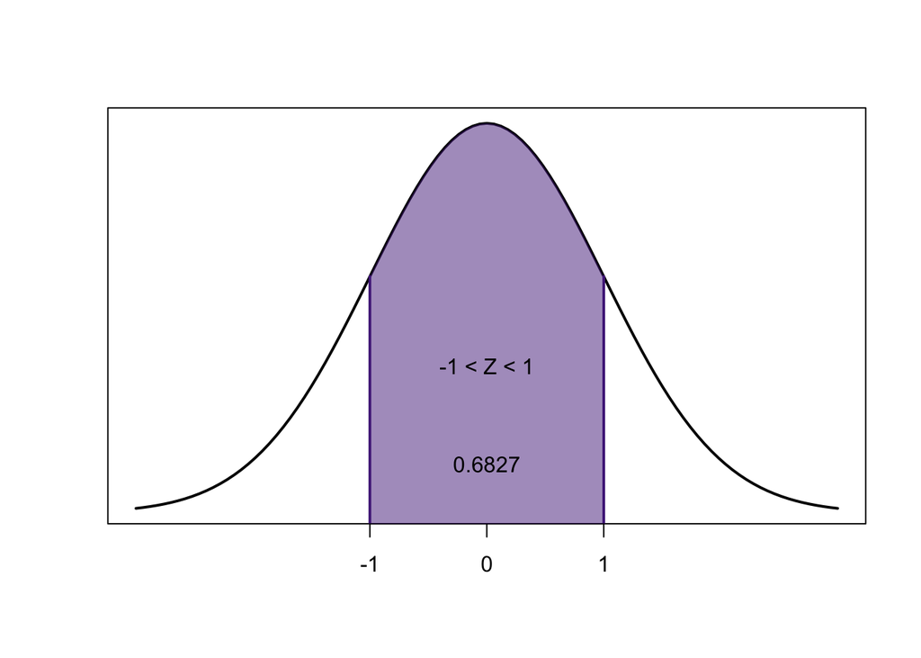

$$0.8413-0.1586=0.6827$$

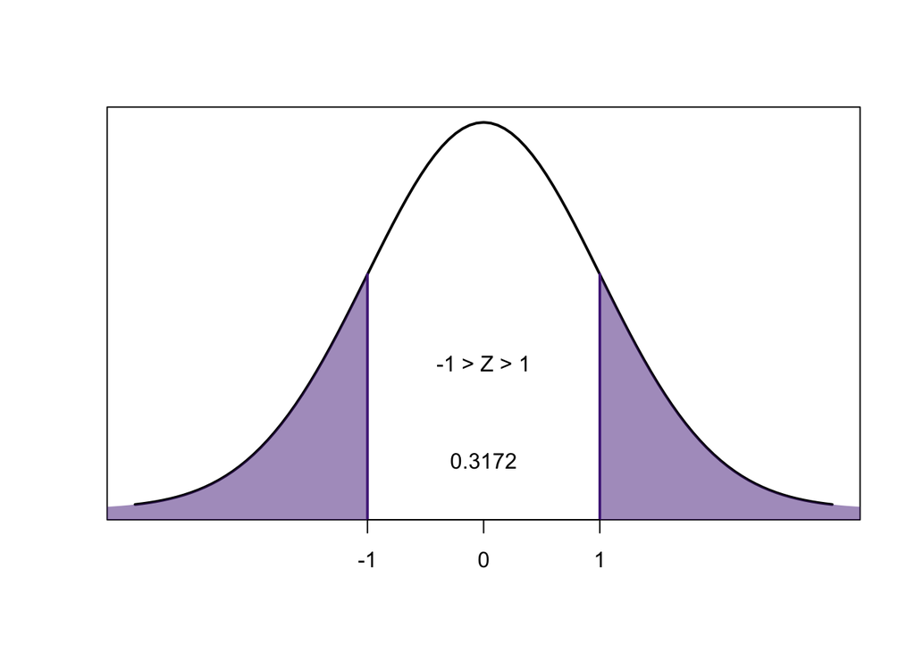

$$1-0.6827=0.3173$$

**A tool for your toolbox**

$$1-0.1586=0.8414 \newline 0.8414-0.1586=0.6828$$

*What have we done?*

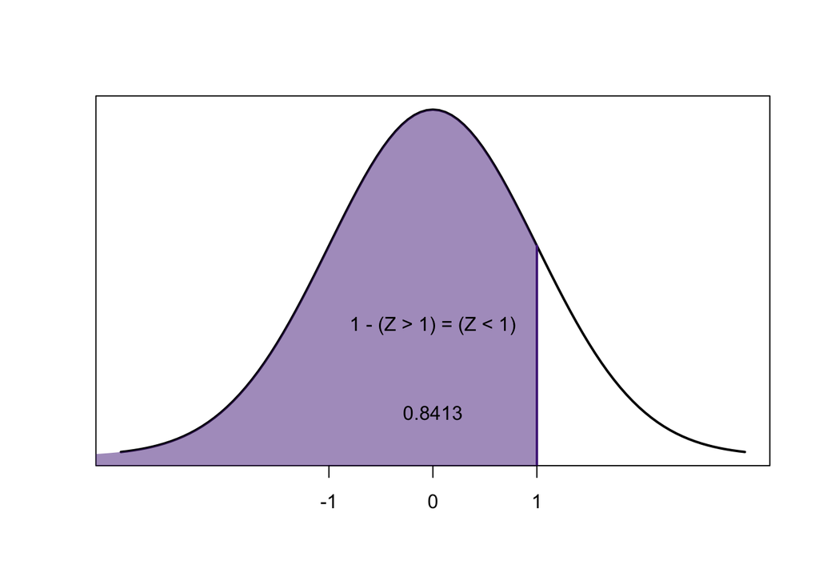

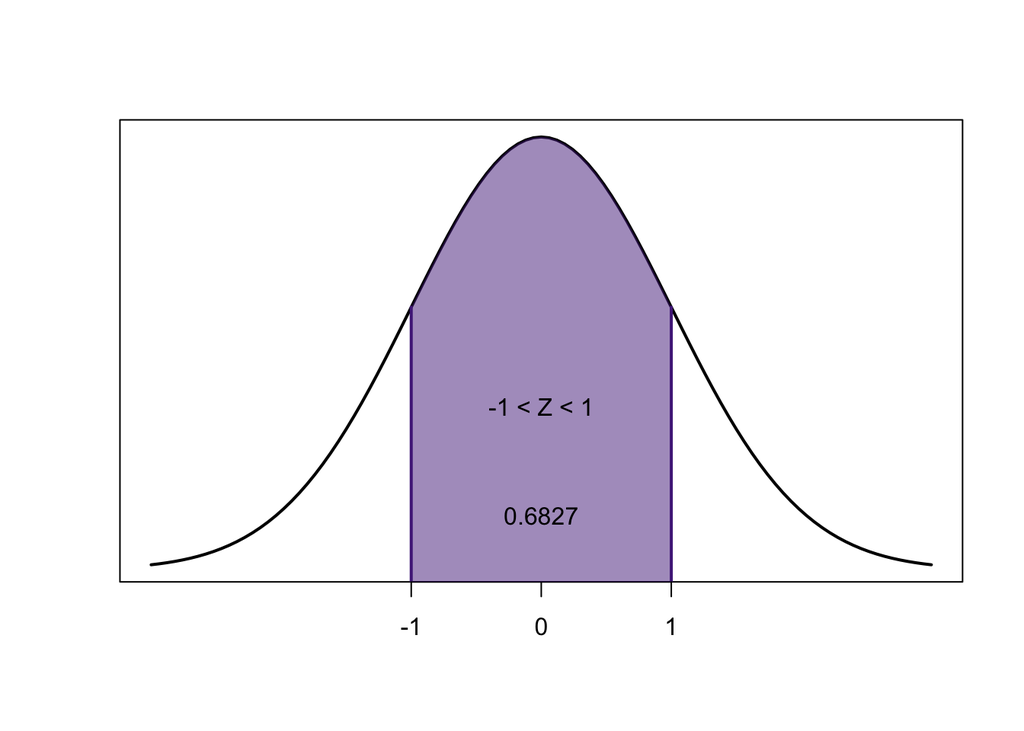

**Questions?**

**Goals for today:**

1. Apply the $z$-score method for non-standard Normal data
2. Build a conceptual framework for sampling distributions
3. Define the Central Limit Theory

## The Normal Distribution

### Non-standard Normal Distributions

If $X$ is a normal random variable with mean $\mu$ and standard deviation $\sigma$ we write $X \sim N(\mu,\sigma^2)$

$\sim$ means “is distributed (as)”

$N()$ refers to the normal distribution

> Together we’re saying “X is distributed normal with mean $\mu$ and variance $\sigma^2$
- So if $\mu=100$ and $\sigma=5$ we’ll write $X\sim (100,5^2)$ or $X \sim (100,25)$
- If we write $X \sim (16,5)$ then $\mu=16$ and $\sigma=\sqrt{5}$

We’ve seen that the standard normal distribution is well understood and we can find probabilities, percentiles, etc. “easily” using a $z$-table

If we want to easily learn these things about **non-standard random variables** it would be convenient if we could transform them into **standard normal random variables**

Fortunately we can

$$\text{if} \ X \sim N(\mu,\sigma^2), \ \text{then} \ Z={X-\mu \over \sigma} \sim N(0,1)$$

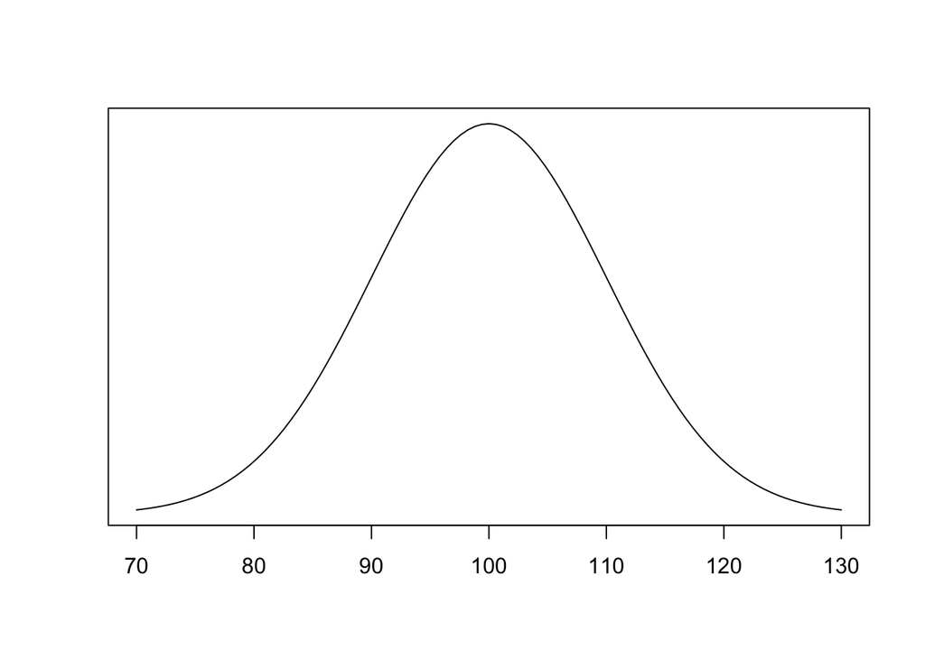

> Say $X=110$

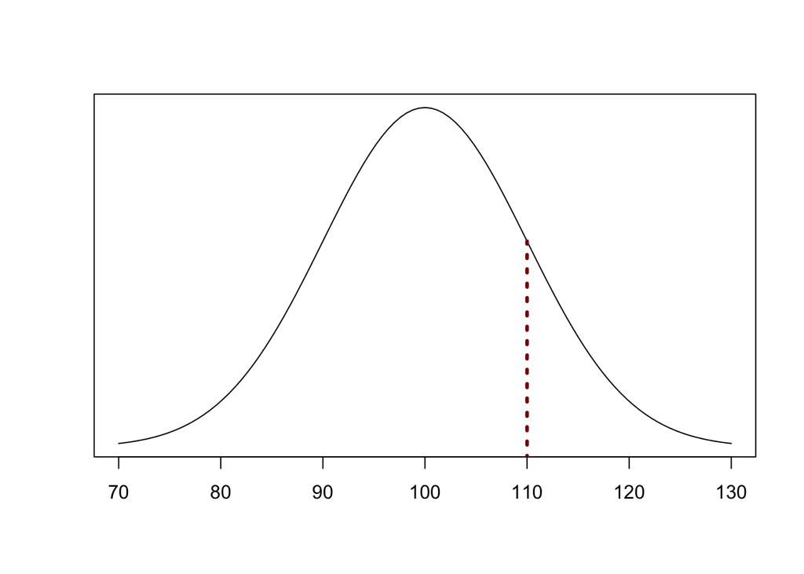

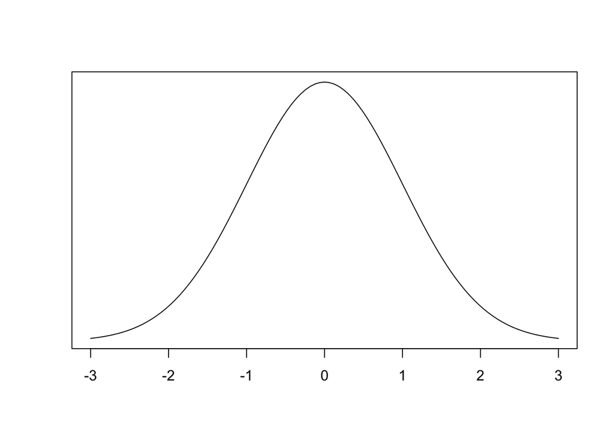

$$Z={110-100 \over 10} =1$$

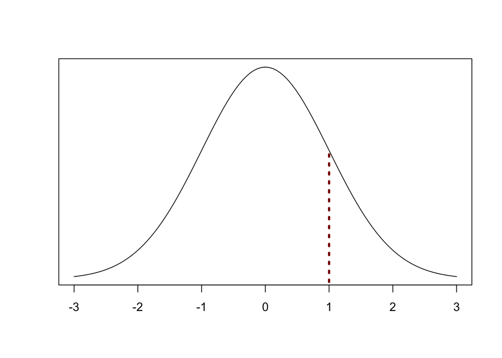

$$z={x-\mu \over \sigma}$$

What we’ve done is convert the non-standard normal distribution into a set of $z$-scores

- What do these $z$-scores measure?

The process we’ve performed in making this conversion is called **standardizing** a normal random variable

- We can do this moving forward to find out information from a non-standard normal r.v. using the $z$-tables

$$P(X\leq x)=P\left({X-\mu \over \sigma}\leq{x-\mu \over \sigma}\right)=P(Z\leq z)$$

> Suppose that the heights of American men ($20$ years and older) are approximately normal with a mean of $70$ inches and a standard deviation of $4$ inches
1. What proportion of American men are less than $6$ feet tall?
- ($6$’ $=$ $72$”)
- $X \sim N(70,4^2)$

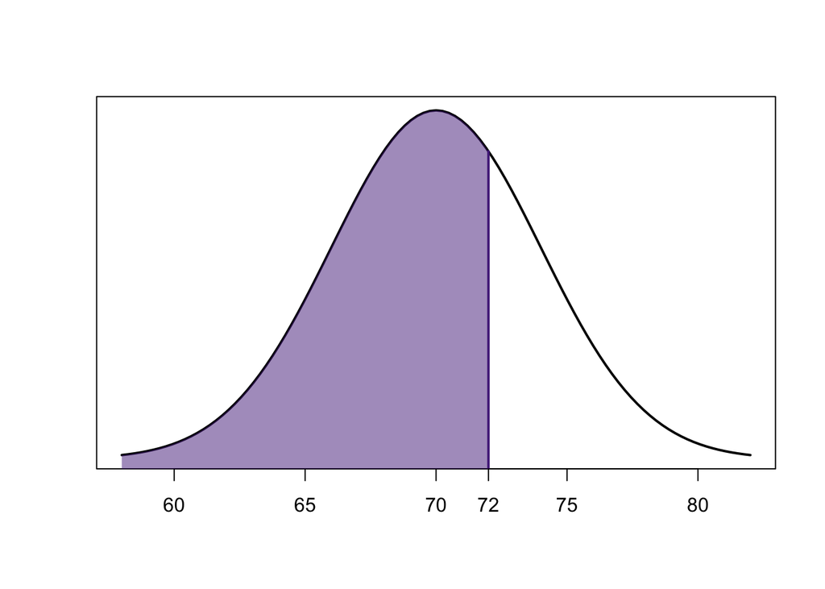

$$P(X\leq 72)=P\left(Z\leq{72-70 \over 4}\right)=P(Z\leq 0.5)$$

[interactive chart not shown]

2. What proportion of American men are between 5’ and 6’ 8”tall?

($5\text{’}=60”$ and $6\text{’}8” = 80”$)

$$P(60<X<80)=P\left({60-70 \over 4}<Z<{80-70 \over 4}\right)$$

We know that for any $z$-score, the area to the left of the negative is exactly equal to the area to the right of the positive:

So:

$$=1-2(\ \ \ \ \ \ \ \ \ \ \ \ \ \ \ \ \ \ \ \ \ )=$$

Given our height example ($X \sim N(70,4^2)$), how tall would you have to be so that you are taller than $90\%$ of American men?

Refer to your $z$-table

Find the closest value to $0.90$

“un-standardize” the value:

$$x=\sigma z + \mu=4( \ \ \ \ \ \ \ \ \ \ \ \ \ ) + 70 =$$

What is an interval of two heights that contains approximately $50\%$ of American men?

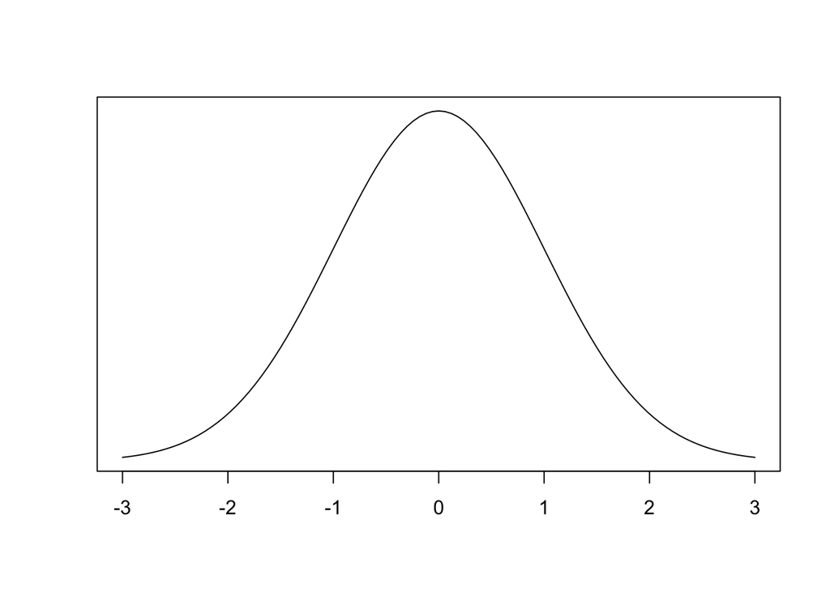

Find a value on your $z$-table that is approximately $0.25$ or $0.75$

- Why these values?

We should end up with $0.67$ at $0.75$

- at $0.25$ it should be $-0.67$

$$x=\sigma (-z) + \mu=4(-0.67) + 70 =67.32$$

$$x=\sigma z + \mu=4(0.67) + 70 =72.68$$

### Sampling Distribution of Sample Mean & Central Limit

Let’s remember some core vocabulary:

- **Population**: The entire collection of individuals we’re seeking information from
- **Sample**: A subset of a population of which we can gather real observations from
- **Parameter**: A value derived from a population
- **Statistic**: A value derived from a sample

*Realistically* we will never quantify a **parameter** directly from a **population**

- The major goal of the statistical sciences is to make **inference** about a **population** and its **parameters** by gathering a **sample** and deriving **statistics**

In practice:

Start with a research question

- “How effective are seasonal Influenza vaccine campaigns in Kansas?”

$$\begin{array}{|c|c|c|c|}
\hline
\text{Population} & \text{Parameter} & \text{Sample} & \text{Statistic } \\
\hline
\text{Kansas Residents} & p_V & 10 \ \text{Kansas Towns} & \hat{p}_V\\
\hline
\\
\hline
\\
\hline
\\
\hline
\end{array}$$

> Business Week reported on the cost per treatment of Herceptin, a drug used to treat breast cancer. Typical treatment costs (in dollars) for Herceptin are provided by a simple random sample of 5 patients.

$$\begin{array}{|c|c|c|c|c|}
\hline
4376 & 5578 & 2717 & 4920 & 4495 \\
\hline
\end{array}$$

Find a number that can be used as an estimate of the mean cost per treatment with Herceptin.

> Suppose we are interested in determining the average time (in minutes) it takes K-State students to travel to their hometowns.
- We take a simple random sample of 100 K-State students, ask each selected student how long it takes to travel home, and then compute the sample mean:

$$\bar{x} = 91.34$$

> Suppose we take another sample of 100 K-State students. This time our sample mean is:

$$\bar{x} = 89.63$$

- If we view taking a random sample as an experiment, then the sample mean $\bar{x}$ is a numerical value assigned to each outcome of the experiment.

We’ve discussed this previously, $\bar{x}$, our sample mean, is a **random variable**

When our value is arising from a sample, a limited subset of the population, it’s value with vary each time our sample changes

> So all **statistics** derived from a sample are **random variables**

This is a fundamental concept to grasp for **all** of statistics:

> All **random variables** have a **random probability distribution**

> As all **statistics** are random variables:

> **All statistics arise from a random probability distribution**

We refer to the probability distribution of a sample statistic as the **sampling distribution**

- We’re going to look at this through the lens of the sample mean

Let $\bar{x}$ be the mean of a random sample of size $n$, drawn from a population with mean $\mu$ and standard deviation $\sigma$

Since $\bar{x}$ is a random variable, it has the mean and the standard deviation

The mean of $\bar{x}$ is $\mu$

$$\mu_{\bar{x}} = \mu = \text{population mean}$$

The standard deviation of $\bar{x}$ is $\sigma / \sqrt{n}$

$$\sigma_{\bar{x}} = \frac{\sigma}{\sqrt{n}}$$

**a.** A population has mean $\mu = 6$ and standard deviation $\sigma = 4$. Find $\mu_{\bar{x}}$ and $\sigma_{\bar{x}}$ for a sample size of $n = 25$

**b.** A population has mean $\mu = 17$ and standard deviation $\sigma = 20$. Find $\mu_{\bar{x}}$ and $\sigma_{\bar{x}}$ for a sample size of $n = 100$

The mean and standard deviation of the sample mean $\bar{x}$ are

$$\mu_{\bar{x}} = \mu$$

$$\sigma_{\bar{x}} = \frac{\sigma}{\sqrt{n}}$$

This is true even when the true values of $\mu$ and $\sigma$ are unknown

This is how we make inference about population parameters with only sample statistics

We know the values of two parameters associated with the sampling distribution of $\bar{x}$